# Social Media Observation Survey

## Social Media Observation Survey

This survey is designed to gain a deeper understanding of individual preferences and behaviours related to their use of social media platforms. It collects a variety of observational data points, including the estimated amount of time users spend on social media each day, how frequently they engage with content, the types of content they interact with (such as videos, photos, text posts, or stories), and the number and variety of platforms they actively use (such as Instagram, TikTok, Facebook, Twitter/X, etc.).

By gathering these information from the survey, it aims to provide a comprehensive overview of social media usage across different users. The data collected will be valuable for identifying trends in digital behaviour, such as which platforms are most popular and what kinds of content drive the most engagement. These insights can help inform future studies on digital well-being and the evolving role of social media in everyday life. Additionally, it offers an objective look into actual usage behaviours, making it particularly useful for statistical analysis and visual storytelling which can further improve out understanding of features like how algorithms used by social media platforms may impact what users see.

## Results

### Graph 1 - Average Engagement Time by Favourite App

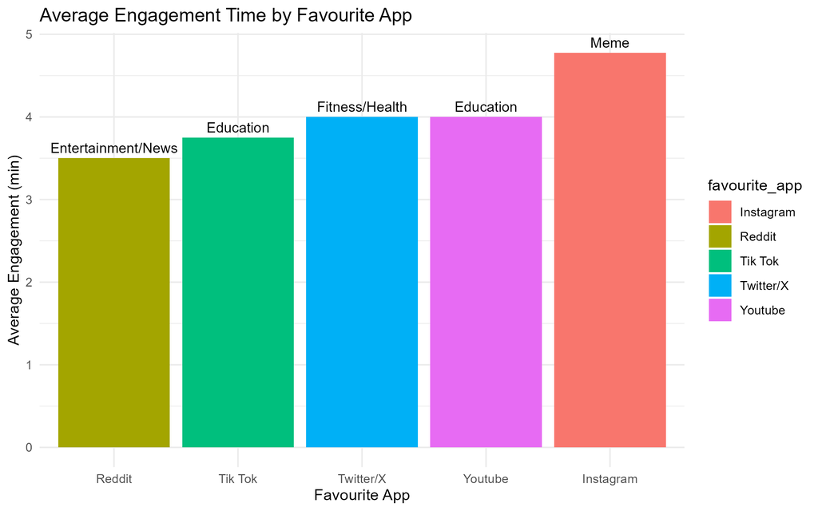

Plot 1 - Average Engagement Time by Favourite App

Based on the collected logged data, this bar chart (using **geom_col**) visualizes the average engagement time for each favourite app (in minutes). Each bar (on the x-axis) represents a different apps and the y-axis indicating, on average, how long users are engaging and spending time on the specified app. This information is useful as it provides an insight into if there are any correlation between the app and the engagement time. Using this data, we can see that, for the most part, the results are relatively similar. Furthermore, for each social media platform, the graph provides which type of content is the most popular at the top. We can use this to see the relation on how the content type on which platform has the most amount of engagement time on average.

### Graph 2 - Engagement Time by Content Type

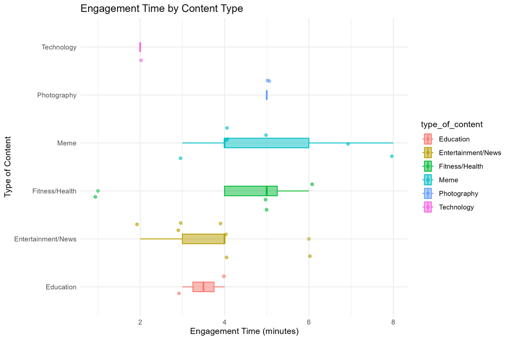

Plot 2 - Engagement Time by Content Type

This plot is a continuation from first graph. This is a combination of a scatter plot and a box plot (using **geom_jitter()** and **geom_boxplot()**) that visualizes the specific variations in user engagement time across different content types. THe combination approach allows for a comprehensive view of the data by providing both a clear summary of the distribution (eg median, quartiles, and outliers) and a detailed view of individual data points. This approach enhances the ability to identify patterns, outliers, and compare the variability across different groups more effectively.

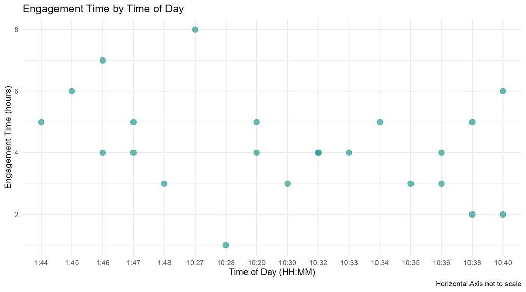

This plot uses the **geom_point** function to create a graph which illustrates the engagement time by time of day. It shows each data point to a specific time of day (**hour_minute**) and the corresponding engagement duration (**engagement_time**). Overall, this plot helps to identify patterns or clustering of engagement throughout the day.

### Summary

The provided analysis consists of three visualizations that collectively explore user engagement patterns across apps. The engagement time was key variable and was compared to social media platforms, content types, and time of day. The engagement time is key as it allows for a deeper understanding of how users interact with social media on a daily basis. By examining this alongside favorite platforms and the type of content consumed, we can identify trends and patterns.